# NDFS Synthesis Manuscript: Chlorophyll analysis

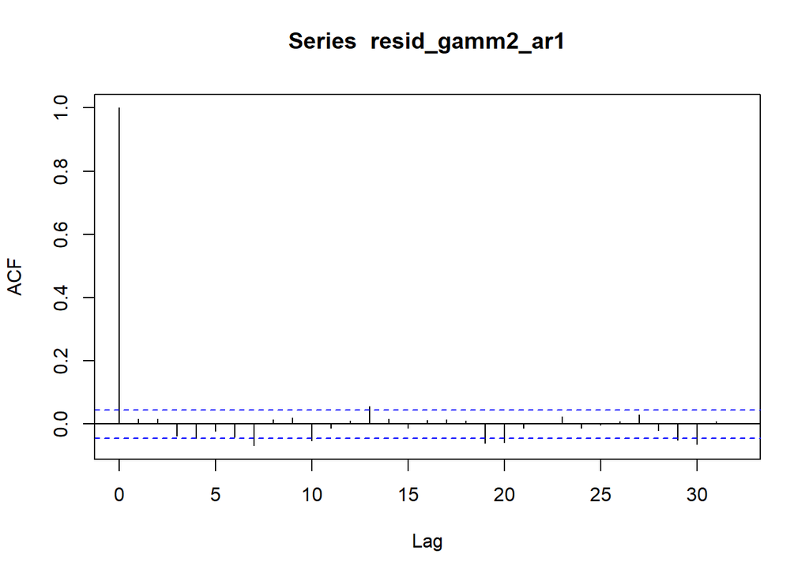

```r
acf(resid_gamm2_ar1)
```

```r
Box.test(resid_gamm2_ar1, lag = 20, type = 'Ljung-Box')
```

```
##
##  Box-Ljung test
##
## data:  resid_gamm2_ar1
## X-squared = 48.902, df = 20, p-value = 0.0003175
```

The AR(1) model has much less residual autocorrelation, and the diagnostics plots look okay. Let’s take a closer look at how the back-transformed fitted values from the model match the observed values.

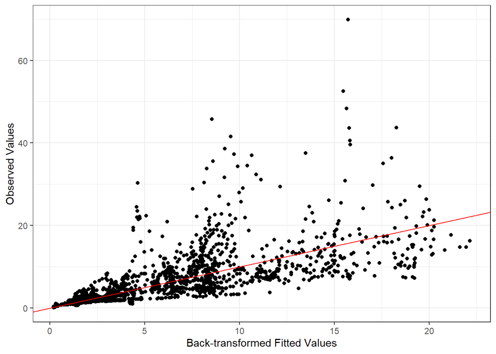

```r
df_gamm2_ar1_fit <- df_chla_c2 %>%
  fitted_values(m_gamm2_ar1_gam, data = .) %>%
  mutate(fitted_bt = exp(fitted) / 1000)

plt_gamm2_ar1_obs_fit <- df_gamm2_ar1_fit %>%
  ggplot(aes(x = fitted_bt, y = Chla)) +
  geom_point() +
  geom_abline(slope = 1, intercept = 0, color = "red") +
  theme_bw() +
  labs(
    x = "Back-transformed Fitted Values",
    y = "Observed Values"
  )

plt_gamm2_ar1_obs_fit
```

Let’s look at each Station and Year separately.

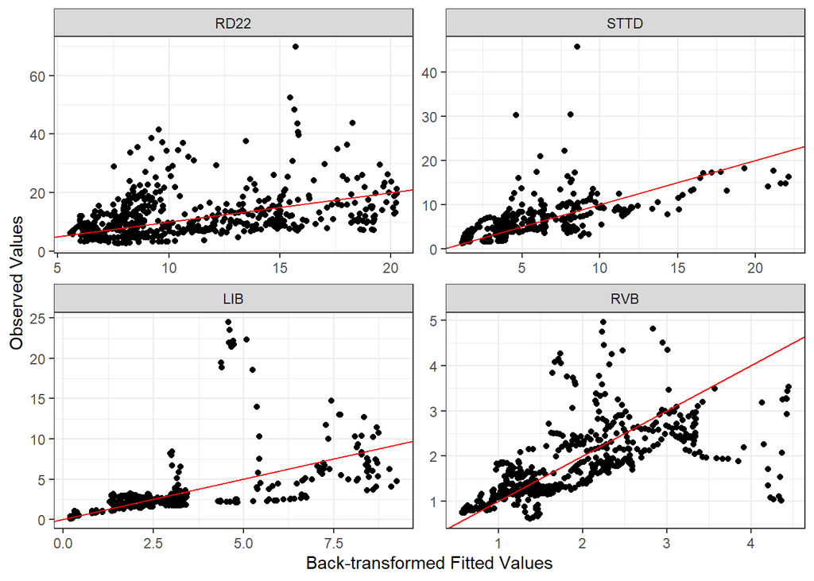

```r
plt_gamm2_ar1_obs_fit + facet_wrap(vars(StationCode), scales = "free")
```

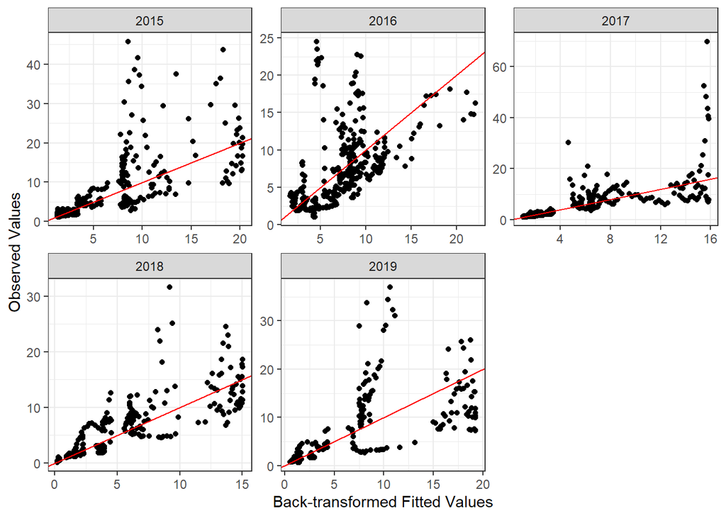

```r
plt_gamm2_ar1_obs_fit + facet_wrap(vars(Year_fct), scales = "free")
```

The red lines are the 1:1 ratio between fitted and observed values, and we would expect for most of the points to be near this line if the model has a good fit to the observed data. However, the fitted values from the model don’t appear to match the observed values that well. Again, I don’t think this GAM model is a good candidate to use for our analysis.

# Linear Model with 2-way interactions

Since the models using 3-way interactions don’t seem to fit the observed data that well, let’s try a linear model using all two-way interactions between Year, Daily Average Flow, and Station. Initially, we’ll run the model without accounting for serial autocorrelation.

## Initial Model

```r
m_lm2 <- df_chla_c2_lag %>%
  drop_na(Chla_log) %>%
  lm(Chla_log ~ (Year_fct + Flow + StationCode)^2, data = .)
```

Lets look at the model summary and diagnostics:

```r
summary(m_lm2)
```

```
##
## Call:
## lm(formula = Chla_log ~ (Year_fct + Flow + StationCode)^2, data = .)
##
## Residuals:
##     Min      1Q  Median      3Q     Max
## -1.5367 -0.2393 -0.0399  0.2061  1.9457
##
## Coefficients:
##                                Estimate Std. Error t value Pr(>|t|)
## (Intercept)                   9.633e+00  4.043e-02 238.279  < 2e-16 ***
## Year_fct2016                 -3.556e-01  5.747e-02  -6.188 7.43e-10 ***
## Year_fct2017                 -3.852e-01  5.474e-02  -7.038 2.71e-12 ***
## Year_fct2018                 -2.924e-01  5.249e-02  -5.569 2.92e-08 ***
## Year_fct2019                 -1.411e-01  5.280e-02  -2.671 0.007619 **
## Flow                         -1.529e-03  9.697e-05 -15.764  < 2e-16 ***
## StationCodeSTTD              -9.934e-01  5.570e-02 -17.835  < 2e-16 ***
## StationCodeLIB               -2.106e+00  1.139e-01 -18.485  < 2e-16 ***
## StationCodeRVB               -2.159e+00  1.073e-01 -20.117  < 2e-16 ***
## Year_fct2016:Flow            -1.249e-04  3.167e-05  -3.945 8.28e-05 ***
## Year_fct2017:Flow            -7.386e-05  2.731e-05  -2.704 0.006909 **
## Year_fct2018:Flow            -1.076e-05  2.737e-05  -0.393 0.694152
## Year_fct2019:Flow            -1.445e-05  2.928e-05  -0.494 0.621605
## Year_fct2016:StationCodeSTTD  7.414e-01  8.173e-02   9.072  < 2e-16 ***
## Year_fct2017:StationCodeSTTD  5.161e-01  8.550e-02   6.037 1.89e-09 ***
## Year_fct2018:StationCodeSTTD -3.377e-01  7.825e-02  -4.316 1.67e-05 ***
## Year_fct2019:StationCodeSTTD -9.968e-01  7.700e-02 -12.945  < 2e-16 ***
## Year_fct2016:StationCodeLIB   1.200e+00  9.360e-02  12.823  < 2e-16 ***
## Year_fct2017:StationCodeLIB   4.159e-01  9.208e-02   4.517 6.67e-06 ***
## Year_fct2018:StationCodeLIB  -1.560e+00  1.125e-01 -13.868  < 2e-16 ***
## Year_fct2019:StationCodeLIB  -3.847e-01  1.150e-01  -3.346 0.000837 ***
## Year_fct2016:StationCodeRVB   1.489e+00  2.227e-01   6.686 3.02e-11 ***
## Year_fct2017:StationCodeRVB   6.563e-01  1.998e-01   3.285 0.001037 **
## Year_fct2018:StationCodeRVB  -8.074e-02  1.636e-01  -0.494 0.621625
## Year_fct2019:StationCodeRVB  -6.171e-01  1.962e-01  -3.145 0.001686 **
## Flow:StationCodeSTTD          3.308e-03  1.377e-04  24.020  < 2e-16 ***
## Flow:StationCodeLIB           1.427e-03  1.140e-04  12.513  < 2e-16 ***
## Flow:StationCodeRVB           1.565e-03  9.550e-05  16.386  < 2e-16 ***
## ---
## Signif. codes:  0 '***' 0.001 '**' 0.01 '*' 0.05 '.' 0.1 ' ' 1
##
## Residual standard error: 0.3979 on 1893 degrees of freedom
## Multiple R-squared:  0.8389, Adjusted R-squared:  0.8366
## F-statistic: 365.2 on 27 and 1893 DF,  p-value: < 2.2e-16
```

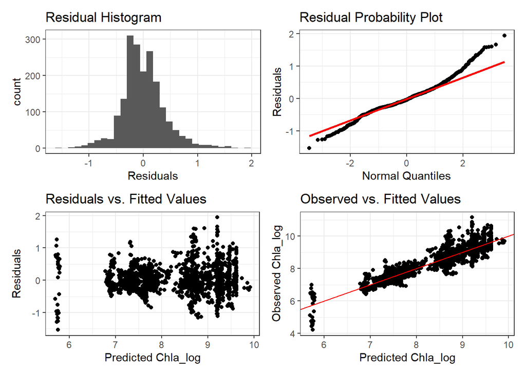

```r
df_chla_c2_lag %>%
  drop_na(Chla_log) %>%
  plot_lm_diag(Chla_log, m_lm2)
```

```r
shapiro.test(residuals(m_lm2))
```

```
##
##  Shapiro-Wilk normality test
##
## data:  residuals(m_lm2)
## W = 0.97046, p-value < 2.2e-16
```

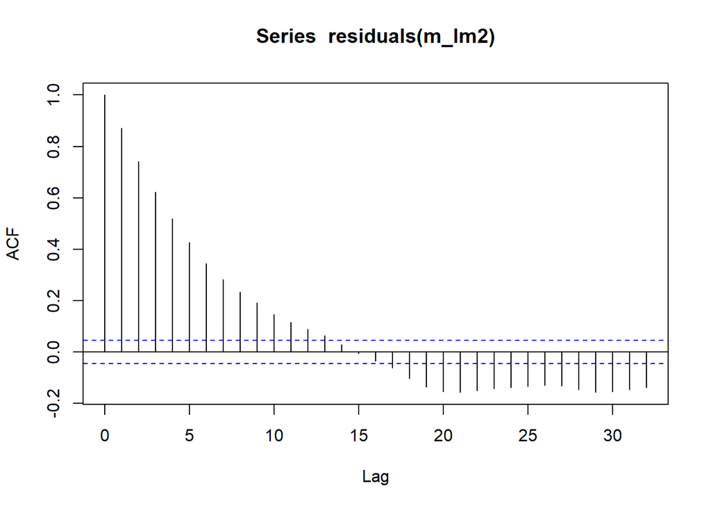

```r
acf(residuals(m_lm2))
```

```r
Box.test(residuals(m_lm2), lag = 20, type = 'Ljung-Box')
```

```
##
##  Box-Ljung test
##
## data:  residuals(m_lm2)
## X-squared = 4904.7, df = 20, p-value < 2.2e-16
```

The residuals deviate from a normal distribution according to visual inspection and the Shapiro-Wilk normality test. Also, model definitely has residual autocorrelation as indicated by the ACF plot and the Box-Ljung test.

### Model with lag terms

Now, we’ll try to deal with the residual autocorrelation and the non-normal residuals. We’ll run a series of linear models adding 1, 2, and 3 lag terms and compare how well they correct for autocorrelation.

#### Lag 1

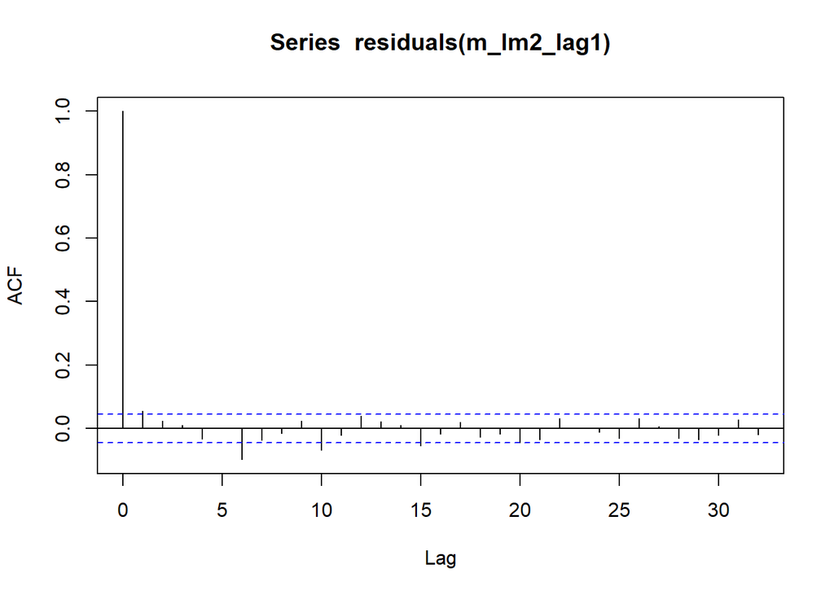

```r
m_lm2_lag1 <- df_chla_c2_lag %>%
  drop_na(Chla_log, lag1) %>%
  lm(Chla_log ~ (Year_fct + Flow + StationCode)^2 + lag1, data = .)

acf(residuals(m_lm2_lag1))
```

```r
Box.test(residuals(m_lm2_lag1), lag = 20, type = 'Ljung-Box')
```

```
##
##  Box-Ljung test
##
## data:  residuals(m_lm2_lag1)
## X-squared = 58.308, df = 20, p-value = 1.297e-05
```

#### Lag 2

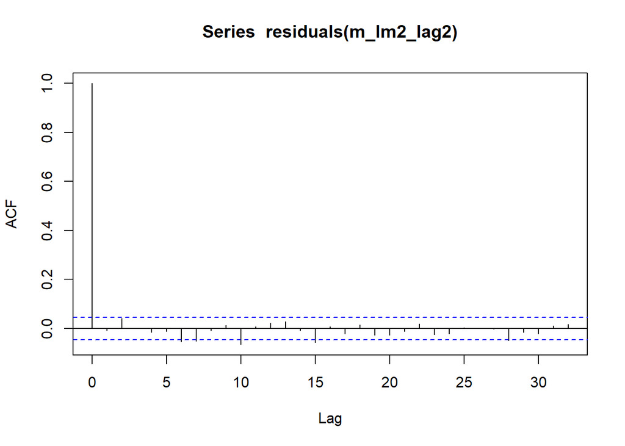

```r
m_lm2_lag2 <- df_chla_c2_lag %>%
  drop_na(Chla_log, lag1, lag2) %>%
  lm(Chla_log ~ (Year_fct + Flow + StationCode)^2 + lag1 + lag2, data = .)

acf(residuals(m_lm2_lag2))
```

```r
Box.test(residuals(m_lm2_lag2), lag = 20, type = 'Ljung-Box')
```

```
##
##  Box-Ljung test
##
## data:  residuals(m_lm2_lag2)
## X-squared = 34.749, df = 20, p-value = 0.02148
```

#### Lag 3

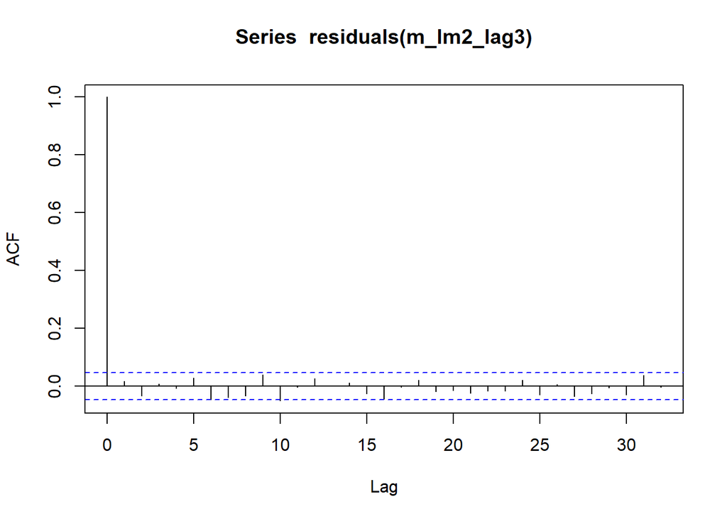

```r
m_lm2_lag3 <- df_chla_c2_lag %>%
  drop_na(Chla_log, lag1, lag2, lag3) %>%
  lm(Chla_log ~ (Year_fct + Flow + StationCode)^2 + lag1 + lag2 + lag3, data = .)

acf(residuals(m_lm2_lag3))
```

```r
Box.test(residuals(m_lm2_lag3), lag = 20, type = 'Ljung-Box')
```

```
##
##  Box-Ljung test
##
## data:  residuals(m_lm2_lag3)
## X-squared = 28.624, df = 20, p-value = 0.09542
```

The model with 3 lag terms looks to have slightly better ACF and Box-Ljung test results than the other models. Let’s compare the 3 models using AIC and BIC to see which model those prefer.

#### Compare models

```r
AIC(m_lm2_lag1, m_lm2_lag2, m_lm2_lag3)
```

```
##            df       AIC
## m_lm2_lag1 30 -1331.263
## m_lm2_lag2 31 -1317.974
## m_lm2_lag3 32 -1299.688
```

```r
BIC(m_lm2_lag1, m_lm2_lag2, m_lm2_lag3)
```

```
##            df       BIC
## m_lm2_lag1 30 -1165.189
## m_lm2_lag2 31 -1147.083
## m_lm2_lag3 32 -1123.919
```

Both AIC and BIC prefer the model with 1 lag term. Let’s take a closer look at that one.

### Lag 1 model summary

```r
summary(m_lm2_lag1)
```

```
##
## Call:
## lm(formula = Chla_log ~ (Year_fct + Flow + StationCode)^2 + lag1,
##     data = .)
##
## Residuals:
##      Min       1Q   Median       3Q      Max
## -1.10990 -0.05742 -0.00637  0.05263  1.08891
##
## Coefficients:
##                                Estimate Std. Error t value Pr(>|t|)
## (Intercept)                   8.621e-01  9.706e-02   8.882  < 2e-16 ***
## Year_fct2016                 -4.466e-02  2.467e-02  -1.810 0.070432 .
## Year_fct2017                 -3.920e-02  2.357e-02  -1.664 0.096380 .
## Year_fct2018                 -2.570e-02  2.248e-02  -1.143 0.253192
## Year_fct2019                  4.008e-04  2.248e-02   0.018 0.985774
## Flow                         -1.624e-04  4.370e-05  -3.717 0.000208 ***
## StationCodeSTTD              -8.197e-02  2.571e-02  -3.188 0.001456 **
## StationCodeLIB               -1.210e-01  5.403e-02  -2.239 0.025270 *
## StationCodeRVB               -1.584e-01  5.049e-02  -3.137 0.001736 **
## lag1                          9.106e-01  9.917e-03  91.816  < 2e-16 ***
## Year_fct2016:Flow            -7.998e-06  1.364e-05  -0.586 0.557696
## Year_fct2017:Flow            -1.197e-06  1.167e-05  -0.103 0.918296
## Year_fct2018:Flow             3.085e-06  1.166e-05   0.265 0.791304
## Year_fct2019:Flow             4.247e-07  1.252e-05   0.034 0.972946
## Year_fct2016:StationCodeSTTD  6.232e-02  3.561e-02   1.750 0.080298 .
## Year_fct2017:StationCodeSTTD  7.283e-02  3.689e-02   1.974 0.048527 *
## Year_fct2018:StationCodeSTTD -3.915e-02  3.345e-02  -1.170 0.242020
## Year_fct2019:StationCodeSTTD -1.145e-01  3.422e-02  -3.345 0.000838 ***
## Year_fct2016:StationCodeLIB   9.269e-02  4.175e-02   2.220 0.026522 *
## Year_fct2017:StationCodeLIB   2.497e-02  3.947e-02   0.632 0.527175
## Year_fct2018:StationCodeLIB  -2.167e-01  5.218e-02  -4.152 3.45e-05 ***
## Year_fct2019:StationCodeLIB  -6.106e-02  5.164e-02  -1.182 0.237206
## Year_fct2016:StationCodeRVB   1.449e-01  9.716e-02   1.491 0.136079
## Year_fct2017:StationCodeRVB   5.911e-02  8.512e-02   0.694 0.487457
## Year_fct2018:StationCodeRVB  -5.716e-03  6.935e-02  -0.082 0.934320
## Year_fct2019:StationCodeRVB  -4.787e-02  8.441e-02  -0.567 0.570736
## Flow:StationCodeSTTD          3.526e-04  6.676e-05   5.281 1.43e-07 ***
## Flow:StationCodeLIB           1.992e-04  5.072e-05   3.928 8.89e-05 ***
## Flow:StationCodeRVB           1.567e-04  4.326e-05   3.622 0.000300 ***
## ---
## Signif. codes:  0 '***' 0.001 '**' 0.01 '*' 0.05 '.' 0.1 ' ' 1
##
## Residual standard error: 0.1682 on 1845 degrees of freedom
## Multiple R-squared:  0.9706, Adjusted R-squared:  0.9701
## F-statistic:  2172 on 28 and 1845 DF,  p-value: < 2.2e-16
```

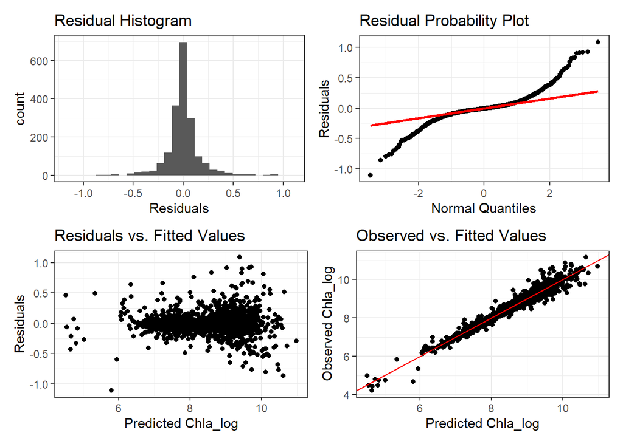

```r
df_chla_c2_lag %>%
  drop_na(Chla_log, lag1) %>%
  plot_lm_diag(Chla_log, m_lm2_lag1)
```

```r
shapiro.test(residuals(m_lm2_lag1))
```

```
##
##  Shapiro-Wilk normality test
##
## data:  residuals(m_lm2_lag1)
## W = 0.86339, p-value < 2.2e-16
```

As with the model with 3-way interactions, the residuals deviate from a normal distribution particularly at the both tails of the distribution. I’m not so sure about using this model. Let’s take a closer look at how the back-transformed fitted values from the model match the observed values.

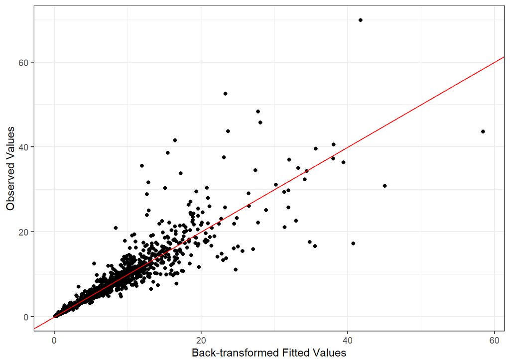

```r
df_lm2_lag1_fit <- df_chla_c2_lag %>%
  drop_na(Chla, lag1) %>%
  mutate(Fitted = as_tibble(predict(m_lm2_lag1, interval = "confidence"))) %>%
  unnest_wider(Fitted) %>%
  mutate(across(c("fit", "lwr", "upr"), ~ exp(.x) / 1000))

plt_lm2_lag1_obs_fit <- df_lm2_lag1_fit %>%
  ggplot(aes(x = fit, y = Chla)) +
  geom_point() +
  geom_abline(slope = 1, intercept = 0, color = "red") +
  theme_bw() +
  labs(
    x = "Back-transformed Fitted Values",
    y = "Observed Values"
  )

plt_lm2_lag1_obs_fit
```

Let’s look at each Station and Year separately.

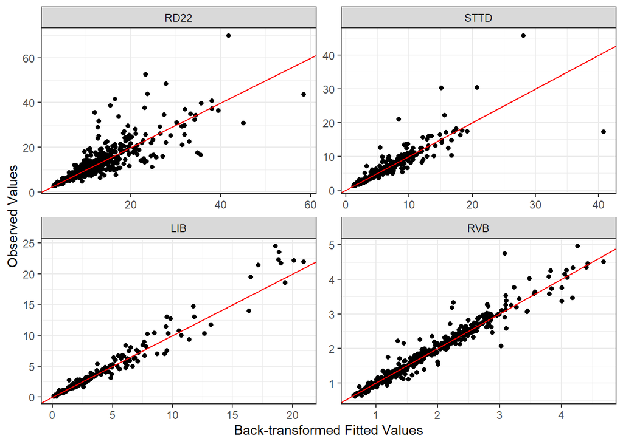

```r
plt_lm2_lag1_obs_fit + facet_wrap(vars(StationCode), scales = "free")
```

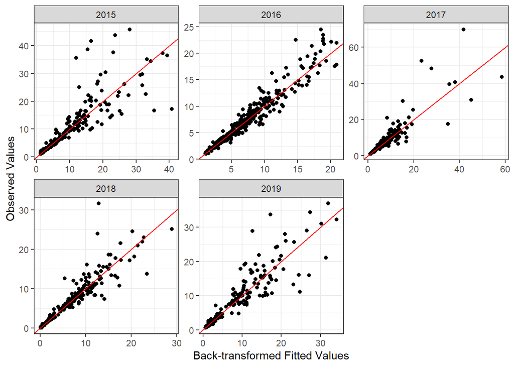

```r
plt_lm2_lag1_obs_fit + facet_wrap(vars(Year_fct), scales = "free")
```

The red lines are the 1:1 ratio between fitted and observed values, and we would expect for most of the points to be near this line if the model has a good fit to the observed data. The fitted and observed values appear to match pretty well at the lower end of the range of values, but this deteriorates at the mid and higher range values. This pattern holds for some of the individual Stations and Years. I’m not sure this linear model is a good candidate to use for our analysis.

### Lag 3 model summary

Let’s take a closer look at the model with 3 lag terms since that had the least autocorrelation.

```r
summary(m_lm2_lag3)
```

```
##
## Call:
## lm(formula = Chla_log ~ (Year_fct + Flow + StationCode)^2 + lag1 +
##     lag2 + lag3, data = .)
##
## Residuals:
##      Min       1Q   Median       3Q      Max
## -1.11082 -0.05607 -0.00690  0.05255  1.12323
##
## Coefficients:
##                                Estimate Std. Error t value Pr(>|t|)
## (Intercept)                   9.973e-01  1.037e-01   9.616  < 2e-16 ***
## Year_fct2016                 -4.170e-02  2.478e-02  -1.682 0.092657 .
## Year_fct2017                 -3.659e-02  2.365e-02  -1.547 0.122072
## Year_fct2018                 -2.643e-02  2.255e-02  -1.172 0.241268
## Year_fct2019                  4.395e-03  2.253e-02   0.195 0.845349
## Flow                         -1.748e-04  4.378e-05  -3.994 6.77e-05 ***
## StationCodeSTTD              -8.615e-02  2.611e-02  -3.299 0.000988 ***
## StationCodeLIB               -1.599e-01  5.592e-02  -2.858 0.004309 **
## StationCodeRVB               -1.834e-01  5.086e-02  -3.607 0.000319 ***
## lag1                          9.620e-01  2.396e-02  40.159  < 2e-16 ***
## lag2                         -7.617e-03  3.309e-02  -0.230 0.817974
## lag3                         -5.869e-02  2.395e-02  -2.450 0.014368 *
## Year_fct2016:Flow            -9.558e-06  1.419e-05  -0.673 0.500724
## Year_fct2017:Flow            -2.255e-06  1.164e-05  -0.194 0.846434
## Year_fct2018:Flow             3.211e-06  1.161e-05   0.277 0.782103
## Year_fct2019:Flow             5.258e-06  1.279e-05   0.411 0.680965
## Year_fct2016:StationCodeSTTD  7.111e-02  3.603e-02   1.973 0.048606 *
## Year_fct2017:StationCodeSTTD  7.658e-02  3.753e-02   2.041 0.041445 *
## Year_fct2018:StationCodeSTTD -4.966e-02  3.363e-02  -1.477 0.139987
## Year_fct2019:StationCodeSTTD -1.379e-01  3.461e-02  -3.984 7.05e-05 ***
## Year_fct2016:StationCodeLIB   1.011e-01  4.269e-02   2.369 0.017957 *
## Year_fct2017:StationCodeLIB   2.753e-02  3.966e-02   0.694 0.487626
## Year_fct2018:StationCodeLIB  -2.237e-01  5.530e-02  -4.045 5.46e-05 ***
## Year_fct2019:StationCodeLIB  -6.390e-02  5.763e-02  -1.109 0.267669
## Year_fct2016:StationCodeRVB   1.545e-01  1.041e-01   1.483 0.138162
## Year_fct2017:StationCodeRVB   5.969e-02  8.535e-02   0.699 0.484390
## Year_fct2018:StationCodeRVB  -1.333e-02  6.896e-02  -0.193 0.846691
## Year_fct2019:StationCodeRVB  -1.159e-01  8.851e-02  -1.310 0.190487
## Flow:StationCodeSTTD          3.796e-04  6.738e-05   5.634 2.04e-08 ***
## Flow:StationCodeLIB           1.999e-04  5.141e-05   3.888 0.000105 ***
## Flow:StationCodeRVB           1.698e-04  4.333e-05   3.919 9.23e-05 ***
## ---
## Signif. codes:  0 '***' 0.001 '**' 0.01 '*' 0.05 '.' 0.1 ' ' 1
##
## Residual standard error: 0.1669 on 1764 degrees of freedom
## Multiple R-squared:  0.9702, Adjusted R-squared:  0.9697
## F-statistic:  1914 on 30 and 1764 DF,  p-value: < 2.2e-16
```

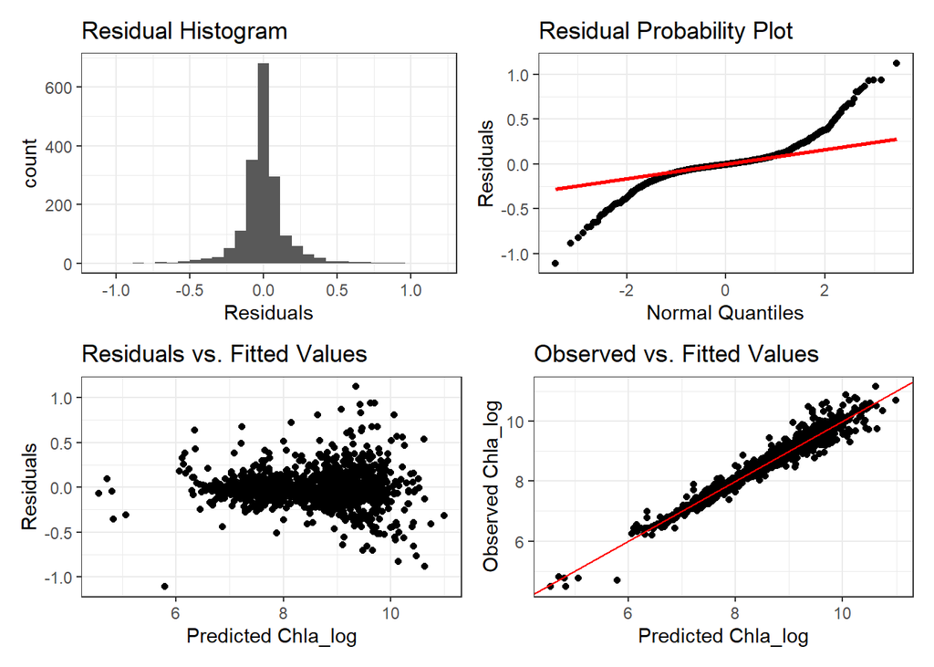

```r
df_chla_c2_lag %>%
  drop_na(Chla_log, lag1, lag2, lag3) %>%
  plot_lm_diag(Chla_log, m_lm2_lag3)
```

```r
shapiro.test(residuals(m_lm2_lag3))
```

```
##
##  Shapiro-Wilk normality test
##
## data:  residuals(m_lm2_lag3)
## W = 0.85552, p-value < 2.2e-16
```

The diagnostic plots show that the lag 3 model has similar problems as the lag 1 model, so this doesn’t look like a good candidate for our analysis as well.

# Linear Model with single station - STTD

Since none of the models we tried so far seemed to fit the observed data very well, it may be interesting to run separate models for each of the four stations - RD22, STTD, LIB, RVB - to see if that helps improve model fit. We’ll try STTD as a test case.

## Initial Model

Let’s try a linear model using a two-way interaction between Year and Daily Average Flow. Initially, we’ll run the model without accounting for serial autocorrelation.

```r
df_sttd <- df_chla_c2_lag %>% filter(StationCode == "STTD")

m_lm2_sttd <- df_sttd %>%
  drop_na(Chla_log) %>%
  lm(Chla_log ~ Year_fct * Flow, data = .)
```

Lets look at the model summary and diagnostics:

```r
summary(m_lm2_sttd)
```

```
##
## Call:
## lm(formula = Chla_log ~ Year_fct * Flow, data = .)
##
## Residuals:
##      Min       1Q   Median       3Q      Max
## -0.78556 -0.17235 -0.02937  0.13767  1.54418
##
## Coefficients:
##                     Estimate Std. Error t value Pr(>|t|)
## (Intercept)        8.6179166  0.0295372 291.765  < 2e-16 ***
## Year_fct2016       0.4259203  0.0459339   9.272  < 2e-16 ***
## Year_fct2017       0.3103625  0.0675065   4.598 5.66e-06 ***
## Year_fct2018      -0.6462877  0.0456684 -14.152  < 2e-16 ***
## Year_fct2019      -1.0607084  0.0444363 -23.870  < 2e-16 ***
## Flow               0.0027158  0.0002046  13.273  < 2e-16 ***
## Year_fct2016:Flow -0.0013946  0.0002864  -4.869 1.59e-06 ***
## Year_fct2017:Flow  0.0051503  0.0017706   2.909  0.00382 **
## Year_fct2018:Flow -0.0004084  0.0002580  -1.583  0.11417
## Year_fct2019:Flow -0.0014040  0.0002321  -6.051 3.19e-09 ***
## ---
## Signif. codes:  0 '***' 0.001 '**' 0.01 '*' 0.05 '.' 0.1 ' ' 1
##
## Residual standard error: 0.3032 on 421 degrees of freedom
## Multiple R-squared:  0.8091, Adjusted R-squared:  0.805
## F-statistic: 198.2 on 9 and 421 DF,  p-value: < 2.2e-16
```

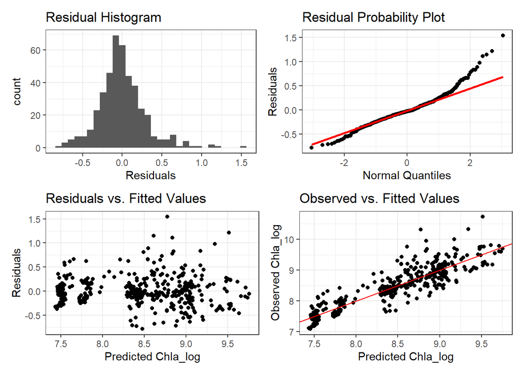

```r
df_sttd %>%
  drop_na(Chla_log) %>%
  plot_lm_diag(Chla_log, m_lm2_sttd)
```

```r
shapiro.test(residuals(m_lm2_sttd))
```

```
##
##  Shapiro-Wilk normality test
##
## data:  residuals(m_lm2_sttd)
## W = 0.94653, p-value = 2.342e-11
```

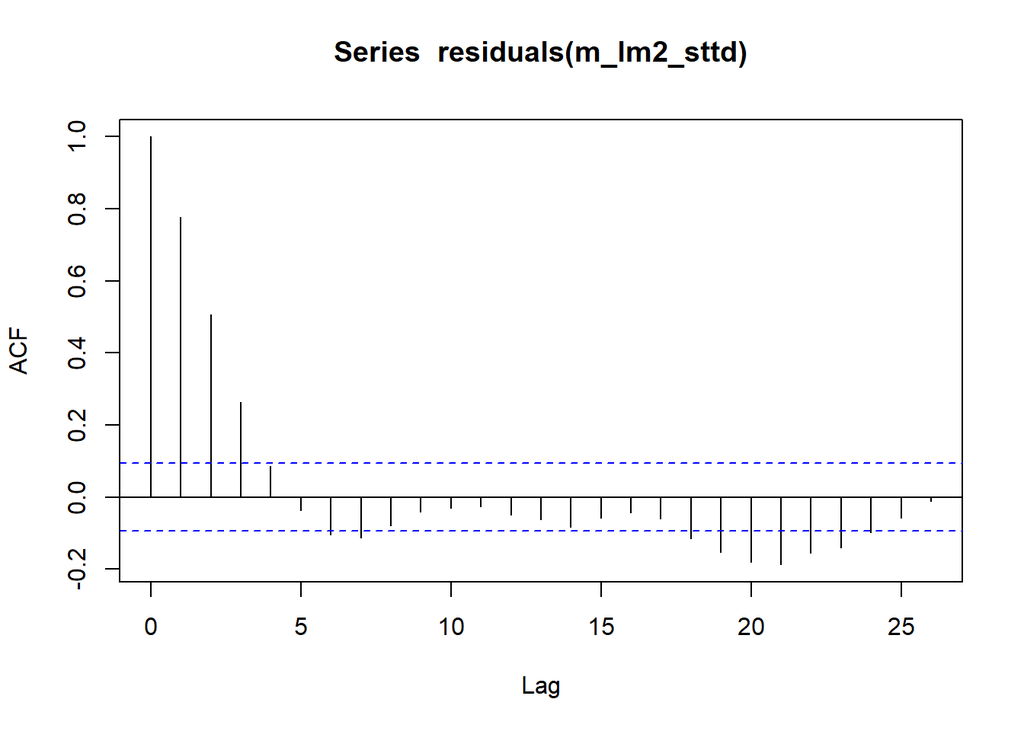

```r
acf(residuals(m_lm2_sttd))
```

```r
Box.test(residuals(m_lm2_sttd), lag = 20, type = 'Ljung-Box')
```

```
##
##  Box-Ljung test
##
## data:  residuals(m_lm2_sttd)
## X-squared = 463.96, df = 20, p-value < 2.2e-16
```

The residuals deviate from a normal distribution according to visual inspection and the Shapiro-Wilk normality test. Also, model definitely has residual autocorrelation as indicated by the ACF plot and the Box-Ljung test.

### Model with lag terms

Now, we’ll try to deal with the residual autocorrelation and the non-normal residuals. We’ll run a series of linear models adding 1, 2, and 3 lag terms and compare how well they correct for autocorrelation.

#### Lag 1

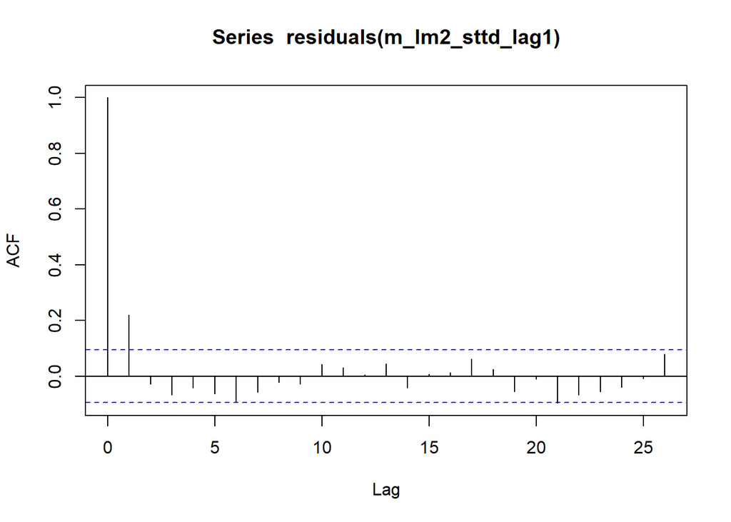

```r
m_lm2_sttd_lag1 <- df_sttd %>%
  drop_na(Chla_log, lag1) %>%
  lm(Chla_log ~ Year_fct * Flow + lag1, data = .)

acf(residuals(m_lm2_sttd_lag1))
```

```r
Box.test(residuals(m_lm2_sttd_lag1), lag = 20, type = 'Ljung-Box')
```

```
##
##  Box-Ljung test
##
## data:  residuals(m_lm2_sttd_lag1)
## X-squared = 37.182, df = 20, p-value = 0.01113
```

#### Lag 2

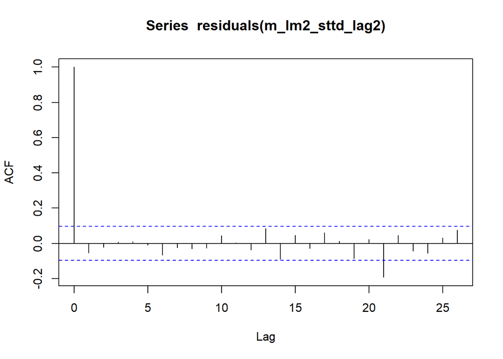

```r
m_lm2_sttd_lag2 <- df_sttd %>%
  drop_na(Chla_log, lag1, lag2) %>%
  lm(Chla_log ~ Year_fct * Flow + lag1 + lag2, data = .)

acf(residuals(m_lm2_sttd_lag2))
```

```r
Box.test(residuals(m_lm2_sttd_lag2), lag = 20, type = 'Ljung-Box')
```

```
##
##  Box-Ljung test
##
## data:  residuals(m_lm2_sttd_lag2)
## X-squared = 18.739, df = 20, p-value = 0.5389
```

#### Lag 3

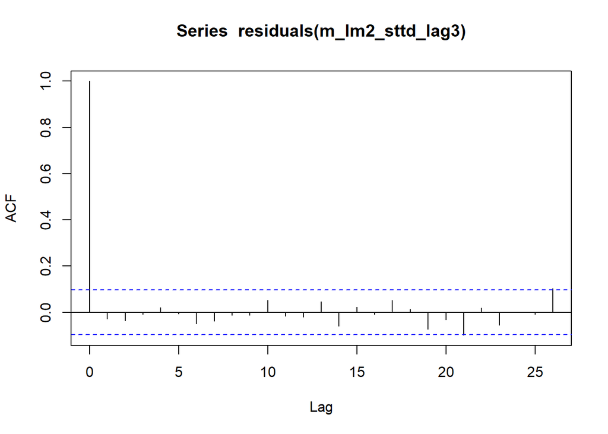

```r
m_lm2_sttd_lag3 <- df_sttd %>%
  drop_na(Chla_log, lag1, lag2, lag3) %>%
  lm(Chla_log ~ Year_fct * Flow + lag1 + lag2 + lag3, data = .)

acf(residuals(m_lm2_sttd_lag3))
```

```r
Box.test(residuals(m_lm2_sttd_lag3), lag = 20, type = 'Ljung-Box')
```

```
##
##  Box-Ljung test
##
## data:  residuals(m_lm2_sttd_lag3)
## X-squared = 10.814, df = 20, p-value = 0.9509
```

The model with 2 lag terms seems to take care of the autocorrelation. Let’s compare the 3 models using AIC and BIC to see which model those prefer.

#### Compare models

```r
AIC(m_lm2_sttd_lag1, m_lm2_sttd_lag2, m_lm2_sttd_lag3)
```

```
##                 df       AIC
## m_lm2_sttd_lag1 12 -328.3102
## m_lm2_sttd_lag2 13 -350.6190
## m_lm2_sttd_lag3 14 -340.5244
```

```r
BIC(m_lm2_sttd_lag1, m_lm2_sttd_lag2, m_lm2_sttd_lag3)
```

```
##                 df       BIC
## m_lm2_sttd_lag1 12 -279.7701
## m_lm2_sttd_lag2 13 -298.3142
## m_lm2_sttd_lag3 14 -284.4699
```

Both AIC and BIC prefer the model with 2 lag terms. Let’s take a closer look at that one.

### Lag 2 model summary

```r
summary(m_lm2_sttd_lag2)
```

```
##
## Call:
## lm(formula = Chla_log ~ Year_fct * Flow + lag1 + lag2, data = .)
##
## Residuals:
##      Min       1Q   Median       3Q      Max
## -0.88419 -0.06597 -0.00902  0.05115  0.81167
##
## Coefficients:
##                     Estimate Std. Error t value Pr(>|t|)
## (Intercept)        1.613e+00  2.285e-01   7.059 7.43e-12 ***
## Year_fct2016       6.865e-02  2.667e-02   2.574 0.010415 *
## Year_fct2017       1.177e-01  3.644e-02   3.230 0.001339 **
## Year_fct2018      -1.292e-01  2.907e-02  -4.445 1.14e-05 ***
## Year_fct2019      -2.085e-01  3.616e-02  -5.767 1.61e-08 ***
## Flow               5.136e-04  1.324e-04   3.878 0.000123 ***
## lag1               1.109e+00  4.925e-02  22.525  < 2e-16 ***
## lag2              -2.955e-01  4.819e-02  -6.132 2.07e-09 ***
## Year_fct2016:Flow -2.826e-04  1.555e-04  -1.818 0.069803 .
## Year_fct2017:Flow  2.695e-03  1.001e-03   2.692 0.007402 **
## Year_fct2018:Flow -5.969e-05  1.375e-04  -0.434 0.664474
## Year_fct2019:Flow -2.504e-04  1.302e-04  -1.922 0.055260 .
## ---
## Signif. codes:  0 '***' 0.001 '**' 0.01 '*' 0.05 '.' 0.1 ' ' 1
##
## Residual standard error: 0.1556 on 401 degrees of freedom
## Multiple R-squared:  0.9497, Adjusted R-squared:  0.9483
## F-statistic: 687.9 on 11 and 401 DF,  p-value: < 2.2e-16
```

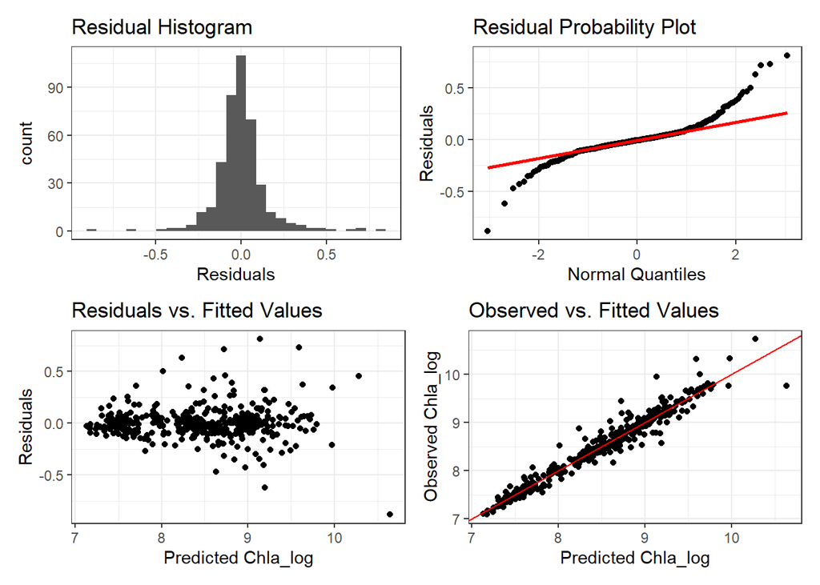

```r
df_sttd %>%
  drop_na(Chla_log, lag1, lag2) %>%
  plot_lm_diag(Chla_log, m_lm2_sttd_lag2)
```

```r
shapiro.test(residuals(m_lm2_sttd_lag2))
```

```
##
##  Shapiro-Wilk normality test
##
## data:  residuals(m_lm2_sttd_lag2)
## W = 0.86609, p-value < 2.2e-16
```

As with all the other linear models, the residuals deviate from a normal distribution particularly at the both tails of the distribution. I’m not so sure about using this model. Let’s take a closer look at how the back-transformed fitted values from the model match the observed values.

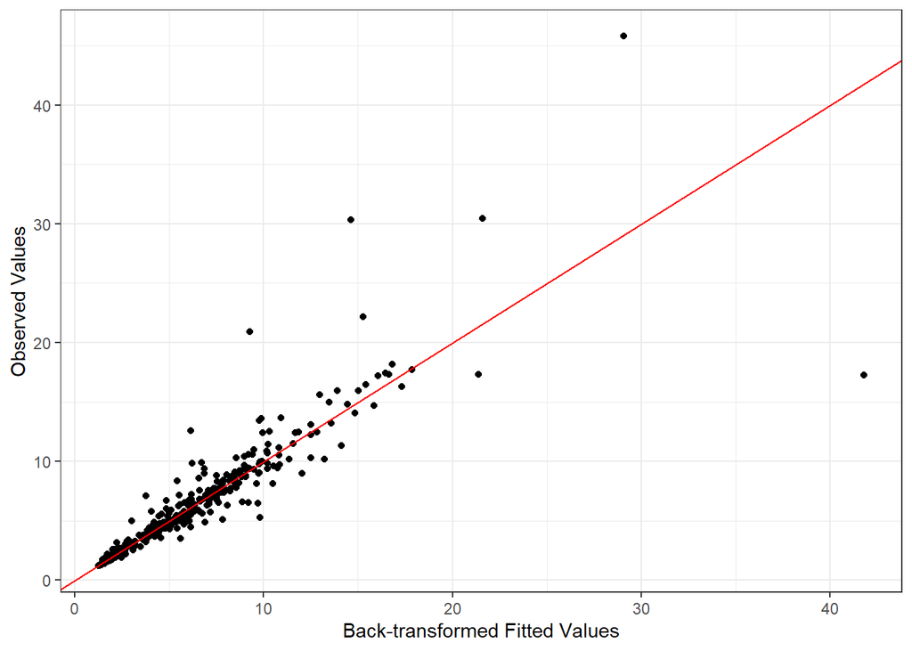

```r
df_lm2_sttd_lag2_fit <- df_sttd %>%
  drop_na(Chla, lag1, lag2) %>%
  mutate(Fitted = as_tibble(predict(m_lm2_sttd_lag2, interval = "confidence"))) %>%
  unnest_wider(Fitted) %>%
  mutate(across(c("fit", "lwr", "upr"), ~ exp(.x) / 1000))

plt_lm2_sttd_lag2_obs_fit <- df_lm2_sttd_lag2_fit %>%
  ggplot(aes(x = fit, y = Chla)) +
  geom_point() +
  geom_abline(slope = 1, intercept = 0, color = "red") +
  theme_bw() +
  labs(
    x = "Back-transformed Fitted Values",
    y = "Observed Values"
  )

plt_lm2_sttd_lag2_obs_fit
```

Let’s look at each Year separately.

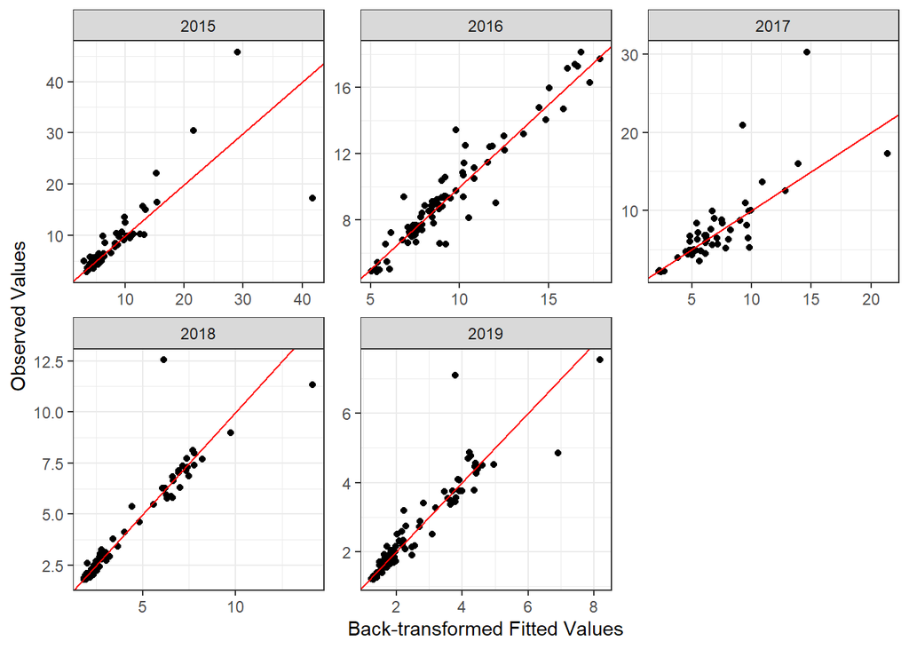

```r
plt_lm2_sttd_lag2_obs_fit + facet_wrap(vars(Year_fct), scales = "free")
```

The red lines are the 1:1 ratio between fitted and observed values, and we would expect for most of the points to be near this line if the model has a good fit to the observed data. The fitted and observed values appear to match pretty well at the lower end of the range of values, but this deteriorates at the higher values. This pattern holds for some of the individual Years. I’m not sure this linear model is a good candidate to use for our analysis.

# Conclusion

None of the models we tried in this analysis seemed to fit the observed data very well. It looks like daily average flow has an effect on chlorophyll concentrations at some of the stations, but flow doesn’t seem to be a good predictor overall. Unfortunately, I don’t think we should use any of these models in our analysis.